# Homework AMG 2019

22 Apr 2019

# Introduction

Differential gene expression analysis is very important in detecting what genes are related to specific disease or clinical condition. Genes discoveried can be focus for developing target treatment. As wikipedia definition, a cancer is the abnormal growth of cells that have the ability to invade or spread to other parts of the body.

The gene activity of those cells in healthy and cancer patients can be measured to discover what genes expressed differently. However, each gene does not work independently but interacts to each other or can be modified by other genes or group of genes. Pathway analysis is very helpful in studying differential gene expression, bring the meaning to high-thoughput biological data.

Analysis for tumor cells of colon cancer patients to see what genes are differently expressed between healthy people and patients. In addition, combining the adjacent cells to tumor of patients for further analysis of gene set enrichment to acquire more knowledge about pathway involve in the colon cancer.

# Data overview

The data contains gene expression profiles of paired tumor sample and a neighbouring normal sample from 98 diseased individuals and 50 samples of healthy control subjects. There are total 18,547 genes are measured for 246 samples. The data set is available as a Gene Expression Omnibus study [GEO:GSE44076](http://www.ncbi.nlm.nih.gov/geo/query/acc.cgi?acc=GSE44076).

| Healthy | Normal | Tumor |
| --- | --- | --- |
| 50 | 98 | 98 |

# Exploring data analysis

## Gene expression

Visualizing the mean of gene expression and the standard deviation, we can see there are some genes have big variant. Based on these values, we can filtering genes for differential expression analysis based on defined threshold.

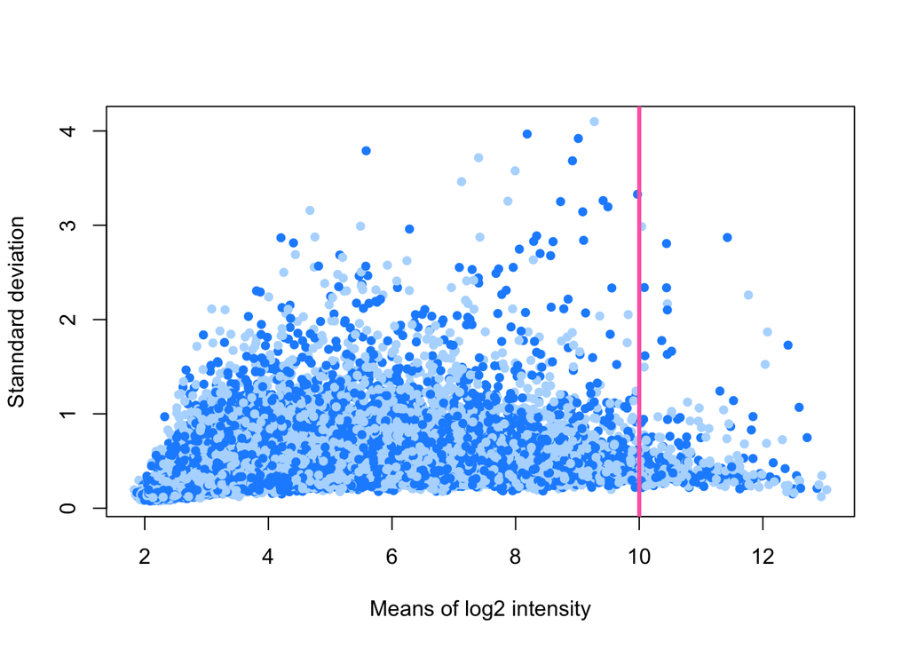

## Unsupervised data exploration

### Spectral maps

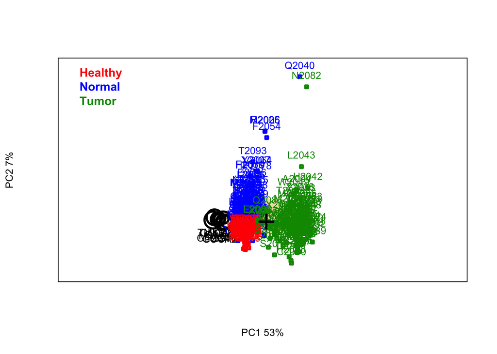

Below spectral expresses clearly two groups of cell typea (normal adjacent versus tumor) which can be distinguished by the first component.

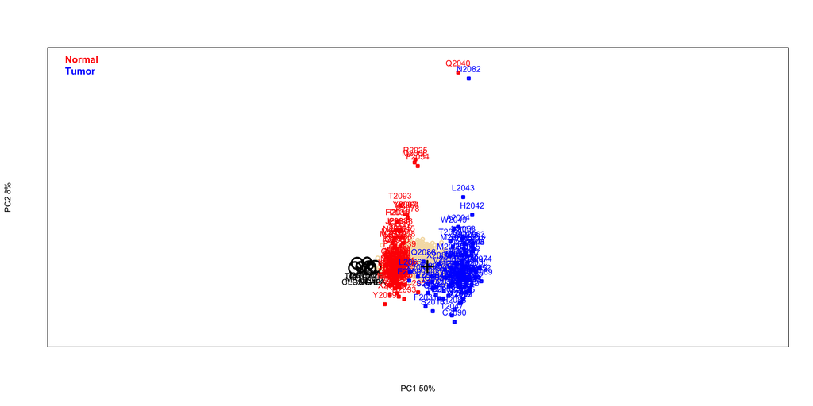

### Singular value decomposition (SVD)

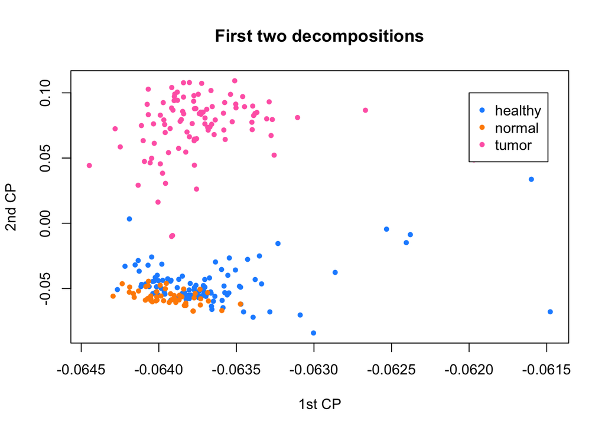

By log2 of the intensity then normalised the expression profiles, the boxplot of gene expression between cell types by first singular composition is presented below. We cansee that, tumor and normal cells are expressed differentially.

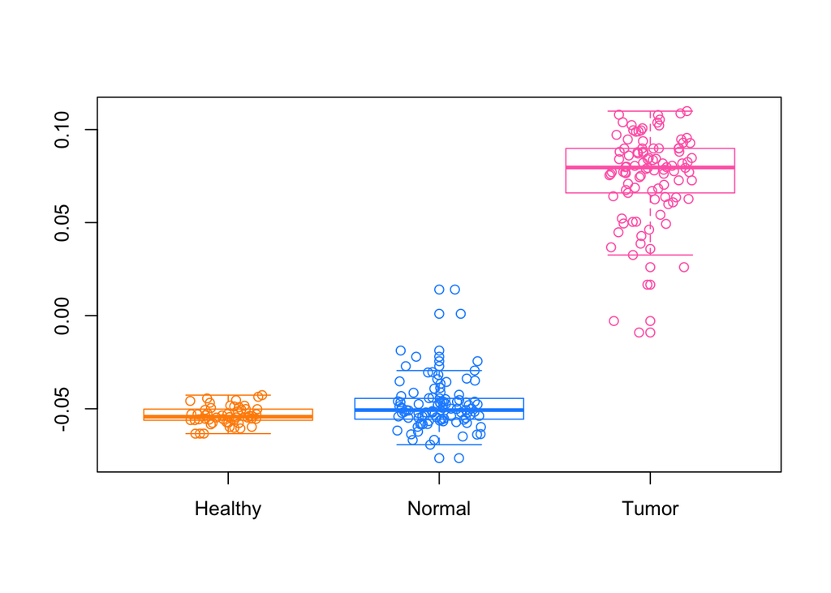

Unsupervised exploring data analysis can label the status of cancer patient for tumor cells. Thus, classification patients versus healthy people can be predicted.

## Filtering

A lots of genes are measured bring the complexity of the d ata set. The data can be filtered to discover significant genes that are differentially expressed between samples, for instance based on variance and intensity, in order to reduce the high-dimensionality and focusing of important genes.

This filter selected 15.4 % of the genes (2863 of the in total 18547 genes). We can use 2863 genes for DE analysis instead of all genes in the profiles.

### Clustering

After filtering out important genes for samples of healthy and tumor cells only, clustering to group the samples to see how classification is between healthy people and cancer patients. As we can see below, disease status is well labeled.

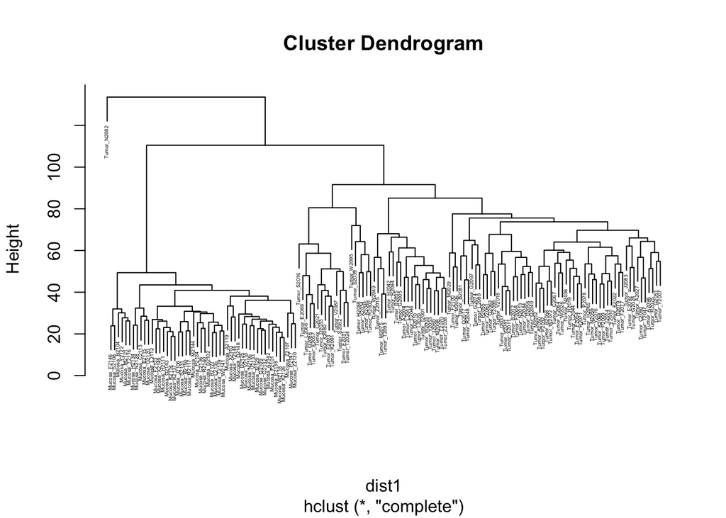

# Detecting differential expression

## Univariate test

By filtering step above, DE analysis can only use 2863 to discovering genes that express differently between normal and tumor cells.

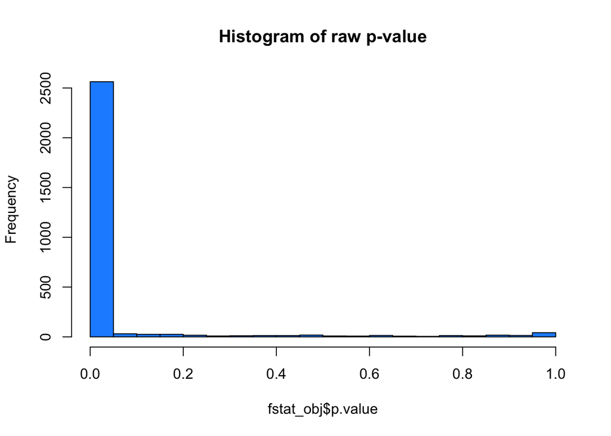

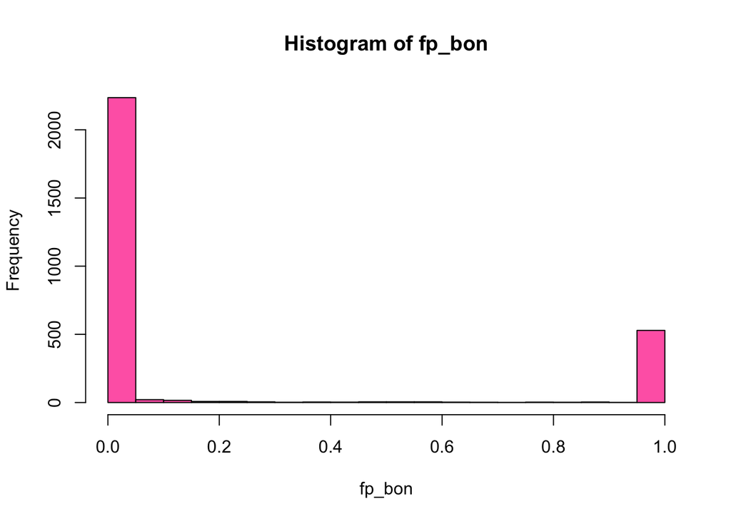

After correcting for multiple testing from univariate test, we have 2236 genes out of 2863 that have significant p-value. Quantile of p-value, we can see most of genes from filtering are expressed differently.

| 0% | 25% | 50% | 75% | 100% |
| --- | --- | --- | --- | --- |
| 6.175e-88 | 8.54e-28 | 8.268e-14 | 0.001997 | 1 |

.

## Adjacent normal cells and tumor cells

Volcano plot for the testing of significant genes between adjacent normal and tumor cells is shown below, there are some top genes highlighted in this plot explain the magnitude of the difference in expression values.

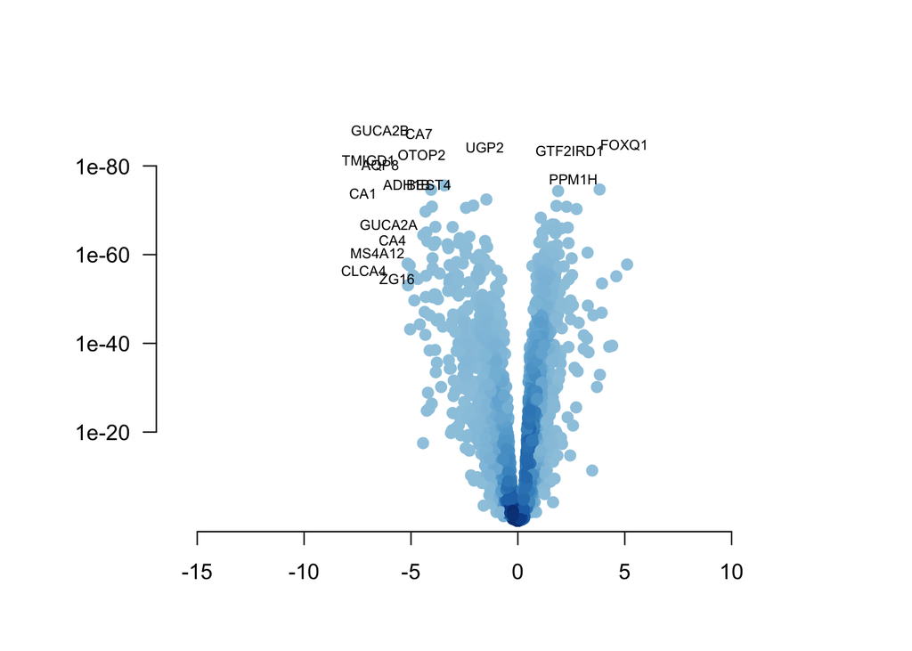

Below are top 10 genes that are expressed differently.

Table continues below

|  | logFC | AveExpr | P.Value | adj.P.Val |
| --- | --- | --- | --- | --- |
| **GUCA2B** | -6.442 | 6.349 | 9.02e-89 | 2.582e-85 |
| **CA7** | -4.623 | 5.116 | 5.9e-88 | 8.446e-85 |
| **FOXQ1** | 4.974 | 5.246 | 1.561e-85 | 1.49e-82 |
| **UGP2** | -1.547 | 11.26 | 5.624e-85 | 4.026e-82 |
| **GTF2IRD1** | 2.423 | 6.004 | 3.477e-84 | 1.991e-81 |
| **OTOP2** | -4.503 | 5.09 | 3.024e-83 | 1.443e-80 |
| **TMIGD1** | -6.983 | 6.647 | 4.367e-82 | 1.786e-79 |
| **AQP8** | -6.434 | 7.131 | 6.499e-81 | 2.326e-78 |
| **PPM1H** | 2.598 | 5.34 | 8.21e-78 | 2.612e-75 |
| **BEST4** | -4.154 | 5.417 | 1.581e-76 | 4.527e-74 |

|  | GENENAME |
| --- | --- |
| **GUCA2B** | guanylate cyclase activator 2B (urogua |
| **CA7** | carbonic anhydrase VII |
| **FOXQ1** | forkhead box Q1 |
| **UGP2** | UDP-glucose pyrophosphorylase 2 |
| **GTF2IRD1** | GTF2I repeat domain containing 1 |
| **OTOP2** | otopetrin 2 |
| **TMIGD1** | transmembrane and immunoglobulin domai |
| **AQP8** | aquaporin 8 |
| **PPM1H** | protein phosphatase, Mg2+/Mn2+ depende |
| **BEST4** | bestrophin 4 |

## Limma for multi factor

Modeling the DE with limma for multiple factors that compare cancer patient with healthy subjects, we get the result as table below.

Table continues below

|  | (Intercept) | as.factor(pdata$type)Normal |
| --- | --- | --- |
| **10000_at** | 1.127e-139 | 7.029e-10 |
| **10001_at** | 4.375e-306 | 0.4705 |
| **10002_at** | 2.521e-207 | 0.4135 |
| **100037417_at** | 3.095e-144 | 0.04801 |
| **100038246_at** | 2.735e-188 | 0.001815 |
| **10003_at** | 2.252e-203 | 0.0001231 |

|  | as.factor(pdata$type)Tumor |
| --- | --- |
| **10000_at** | 0.02437 |
| **10001_at** | 4.445e-11 |
| **10002_at** | 0.1221 |
| **100037417_at** | 0.0004704 |
| **100038246_at** | 0.04994 |
| **10003_at** | 0.1469 |

|  | logFC | AveExpr | t | P.Value | adj.P.Val | B |
| --- | --- | --- | --- | --- | --- | --- |
| **3491_at** | 1.255 | 2.58 | 27.12 | 6.708e-76 | 1.244e-71 | 161.6 |
| **1958_at** | 0.7891 | 2.916 | 22.87 | 7.687e-63 | 7.128e-59 | 132.1 |
| **79785_at** | 1.177 | 1.692 | 22.69 | 2.906e-62 | 1.797e-58 | 130.8 |
| **9510_at** | 0.5943 | 2.624 | 21.19 | 2.037e-57 | 9.446e-54 | 119.8 |
| **1178_at** | -1.051 | 1.875 | -20.88 | 2.048e-56 | 7.599e-53 | 117.5 |
| **6422_at** | 0.813 | 1.825 | 20.1 | 7.731e-54 | 2.39e-50 | 111.7 |
| **2353_at** | 0.7603 | 2.994 | 19.43 | 1.257e-51 | 3.332e-48 | 106.7 |
| **10894_at** | 0.7293 | 2.02 | 19.39 | 1.73e-51 | 4.01e-48 | 106.3 |
| **57124_at** | 0.6499 | 2.528 | 18.34 | 5.769e-48 | 1.167e-44 | 98.34 |
| **1490_at** | 0.5828 | 2.811 | 18.33 | 6.295e-48 | 1.167e-44 | 98.25 |

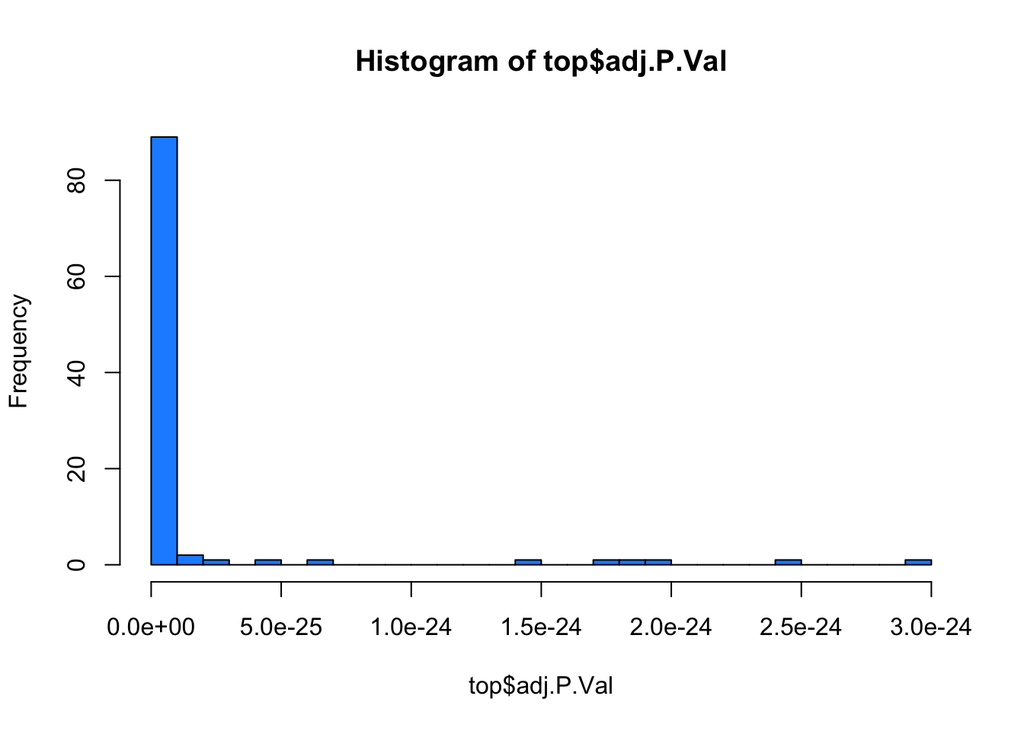

## DE genes between healthy and tumor cells

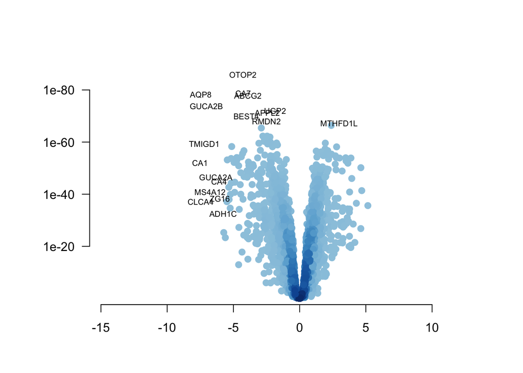

Top 10 genes below are expressed differently between healthy and cancer subjects.

Table continues below

|  | logFC | AveExpr | P.Value | adj.P.Val |
| --- | --- | --- | --- | --- |
| **OTOP2** | -4.281 | 4.285 | 1.274e-86 | 4.017e-83 |
| **CA7** | -4.267 | 4.246 | 2.054e-79 | 3.239e-76 |
| **AQP8** | -7.455 | 6.433 | 4.665e-79 | 4.904e-76 |
| **ABCG2** | -3.906 | 4.718 | 1.251e-78 | 9.864e-76 |
| **GUCA2B** | -7.038 | 5.506 | 1.549e-74 | 9.769e-72 |
| **UGP2** | -1.855 | 11.11 | 9.94e-73 | 5.225e-70 |
| **APPL2** | -2.435 | 6.275 | 6.186e-72 | 2.787e-69 |
| **BEST4** | -4.025 | 4.7 | 1.322e-70 | 5.212e-68 |
| **RMDN2** | -2.508 | 5.366 | 1.138e-68 | 3.989e-66 |
| **MTHFD1L** | 2.979 | 6.138 | 4.929e-68 | 1.555e-65 |

|  | GENENAME |
| --- | --- |
| **OTOP2** | otopetrin 2 |
| **CA7** | carbonic anhydrase VII |
| **AQP8** | aquaporin 8 |
| **ABCG2** | ATP-binding cassette, sub-family G (WH |
| **GUCA2B** | guanylate cyclase activator 2B (urogua |
| **UGP2** | UDP-glucose pyrophosphorylase 2 |
| **APPL2** | adaptor protein, phosphotyrosine inter |
| **BEST4** | bestrophin 4 |
| **RMDN2** | regulator of microtubule dynamics 2 |
| **MTHFD1L** | methylenetetrahydrofolate dehydrogenas |

# Visualization of interesting genes

## Plot the expression levels of one gene

List of DE genes between adjacent normal versus tumor cells and healthy subjects versus cancer patients discovered above can be visualised to see how the expression profiles are different between groups. Below are just some of genes are visualised for the gene expression by cell typs and by groups.

First figure expressed the different expression of gene GUCA2B (guanylate cyclase activator 2B). As we can see, adjacent normal cells have higher value of intensity while tumor cells shows small intensity. However, there are some patients have low expression in normal cells and high intensity in tumor cells.

With gene AQP8, we can see that cancer patients have lower intensity compare to healthy people.

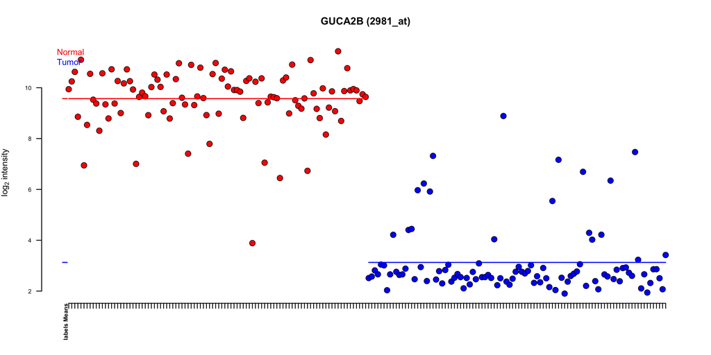

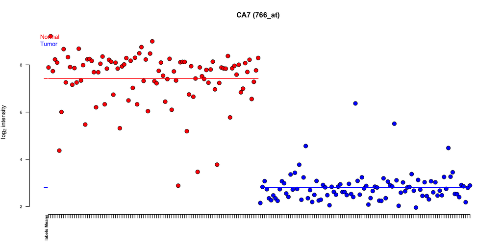

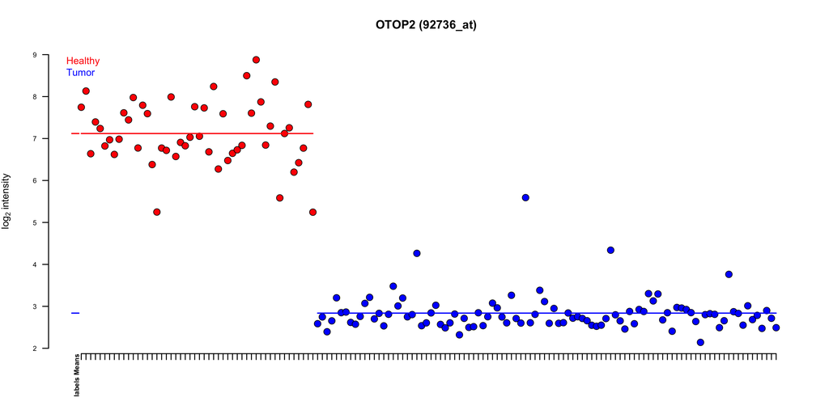

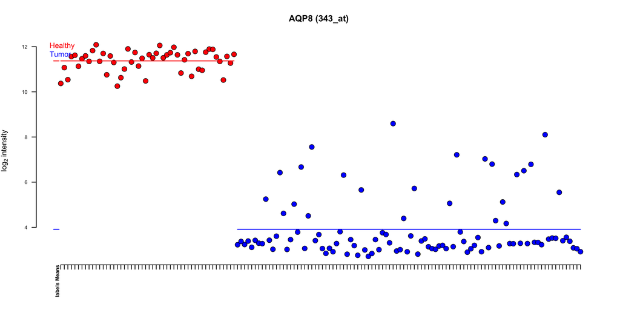

# Pathway analysis

There are numerous database for mapping the biological processes when analysing gene set. In this report, two databaes for annotation of biological pathways are GO term and KEGG to look at the relationship of genes.

## Gene Oncology terms

GO term covers annotation for cellular processes and molecular functions. By mapping DE genes between normal and tumor cells from study, we can get more undersantd about the set of genes by their biological categories.

Table continues below

|  | category | over_represented_pvalue | under_represented_pvalue |
| --- | --- | --- | --- |
| **6460** | GO:0034660 | 9.339e-05 | 1 |
| **1722** | GO:0005730 | 0.0003292 | 0.9999 |
| **6415** | GO:0034470 | 0.00035 | 1 |
| **7159** | GO:0042254 | 0.0004595 | 1 |
| **4766** | GO:0022613 | 0.0005072 | 0.9999 |
| **5994** | GO:0032991 | 0.0006287 | 0.9996 |

Table continues below

|  | numDEInCat | numInCat | term |
| --- | --- | --- | --- |
| **6460** | 131 | 132 | ncRNA metabolic process |
| **1722** | 230 | 237 | nucleolus |
| **6415** | 89 | 89 | ncRNA processing |
| **7159** | 86 | 86 | ribosome biogenesis |
| **4766** | 133 | 135 | ribonucleoprotein complex biogenesis |
| **5994** | 897 | 955 | protein-containing complex |

|  | ontology |
| --- | --- |
| **6460** | BP |
| **1722** | CC |
| **6415** | BP |
| **7159** | BP |
| **4766** | BP |
| **5994** | CC |

Below table presents the GO term for molecular functions based on the DE genes between normal and tumor cells. The number of DE genes in table below expresses the enrichment for specific GO term. Such as in the function of catalytic activity, acting on RNA, there are total 89 genes are DE out of total 91 genes relate to this function.

Table continues below

|  | category | over_represented_pvalue | under_represented_pvalue |
| --- | --- | --- | --- |
| **2439** | GO:0140098 | 0.01362 | 0.9972 |
| **147** | GO:0003723 | 0.03256 | 0.9797 |
| **2440** | GO:0140101 | 0.05905 | 1 |
| **1180** | GO:0016788 | 0.0644 | 0.9714 |
| **2101** | GO:0051082 | 0.08359 | 0.9845 |
| **329** | GO:0004386 | 0.08437 | 1 |

Table continues below

|  | numDEInCat | numInCat | term |
| --- | --- | --- | --- |
| **2439** | 89 | 91 | catalytic activity, acting on RNA |
| **147** | 414 | 441 | RNA binding |
| **2440** | 32 | 32 | catalytic activity, acting on a tRNA |
| **1180** | 125 | 131 | hydrolase activity, acting on ester bonds |
| **2101** | 46 | 47 | unfolded protein binding |
| **329** | 28 | 28 | helicase activity |

|  | ontology |
| --- | --- |
| **2439** | MF |
| **147** | MF |
| **2440** | MF |
| **1180** | MF |
| **2101** | MF |
| **329** | MF |

## KEGG pathway analysis

As we can see above, the DE genes can be visualised one by one to see how different in expression between cell types in cancer patient and between normal cells and tumor cells. However, the profile on gene level do not provide very informative explanation, especially when making comparison between cell types of each patient.

Thus, by combining the gene set and annotate to the biological pathways of genes between normal and tumor cells, pathway analysis map the DE genes to known biological pathways, processes and functions. In this report, KEGG, an existing pathway knowledge, is used to map top genes that are differently expressed obtain in DE analysis above.

| ID | Pathway | Gene set |
| --- | --- | --- |
| hsa00910 | Nitrogen metabolism | 766/759/762 |
| hsa04976 | Bile secretion | 343/8671/9429/123264 |

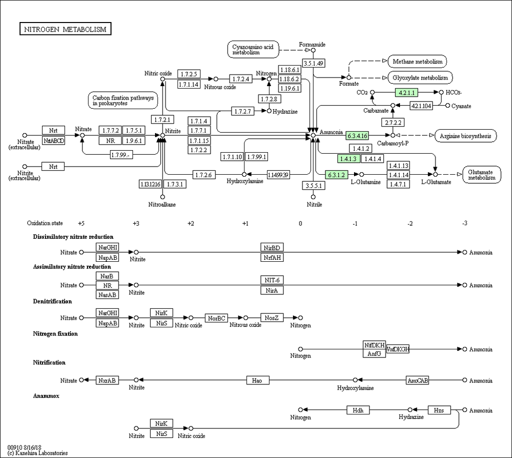

[figure not shown]

# Software used

```
## \begin{itemize}\raggedright
##   \item R version 3.5.3 (2019-03-11), \verb|x86_64-apple-darwin15.6.0|
##   \item Locale: \verb|en_US.UTF-8/en_US.UTF-8/en_US.UTF-8/C/en_US.UTF-8/en_US.UTF-8|
##   \item Running under: \verb|macOS High Sierra 10.13.4|
##   \item Matrix products: default
##   \item BLAS: \verb|/Library/Frameworks/R.framework/Versions/3.5/Resources/lib/libRblas.0.dylib|
##   \item LAPACK: \verb|/Library/Frameworks/R.framework/Versions/3.5/Resources/lib/libRlapack.dylib|
##   \item Base packages: base, datasets, graphics, grDevices, grid,
##     methods, parallel, stats, stats4, utils
##   \item Other packages: a4~1.30.0, a4Base~1.30.0,
##     a4Classif~1.30.0, a4Core~1.30.0, a4Preproc~1.30.0,
##     a4Reporting~1.30.0, annaffy~1.54.0, annotate~1.60.1,
##     AnnotationDbi~1.44.0, BiasedUrn~1.07, Biobase~2.42.0,
##     BiocGenerics~0.28.0, BiocParallel~1.16.6, cluster~2.0.8,
##     clusterProfiler~3.10.1, DelayedArray~0.8.0, dendextend~1.10.0,
##     DESeq2~1.22.2, devtools~2.0.2, foreach~1.4.4,
##     genefilter~1.64.0, geneLenDataBase~1.18.0,
##     GenomeInfoDb~1.18.2, GenomicRanges~1.34.0, glmnet~2.0-16,
##     GO.db~3.7.0, goseq~1.34.1, gplots~3.0.1.1, IRanges~2.16.0,
##     KEGG.db~3.2.3, KernSmooth~2.23-15, limma~3.38.3,
##     MASS~7.3-51.4, Matrix~1.2-17, matrixStats~0.54.0,
##     MLInterfaces~1.62.1, mpm~1.0-22, multtest~2.38.0,
##     org.Hs.eg.db~3.7.0, pamr~1.56, pander~0.6.3, pathview~1.22.3,
##     randomForest~4.6-14, ROCR~1.0-7, S4Vectors~0.20.1,
##     SummarizedExperiment~1.12.0, survival~2.44-1.1, usethis~1.5.0,
##     varSelRF~0.7-8, XML~3.98-1.19
##   \item Loaded via a namespace (and not attached): acepack~1.4.1,
##     assertthat~0.2.1, backports~1.1.4, base64enc~0.1-3,
##     biomaRt~2.38.0, Biostrings~2.50.2, bit~1.1-14, bit64~0.9-7,
##     bitops~1.0-6, blob~1.1.1, callr~3.2.0, caTools~1.17.1.2,
##     checkmate~1.9.1, class~7.3-15, cli~1.1.0, codetools~0.2-16,
##     colorspace~1.4-1, compiler~3.5.3, cowplot~0.9.4, crayon~1.3.4,
##     crosstalk~1.0.0, data.table~1.12.2, DBI~1.0.0, DEoptimR~1.0-8,
##     desc~1.2.0, digest~0.6.18, diptest~0.75-7, DO.db~2.9,
##     DOSE~3.8.2, dplyr~0.8.0.1, enrichplot~1.2.0, europepmc~0.3,
##     evaluate~0.13, farver~1.1.0, fastmatch~1.1-0, fgsea~1.8.0,
##     flexmix~2.3-15, foreign~0.8-71, Formula~1.2-3, fpc~2.1-11.1,
##     fs~1.2.7, gbm~2.1.5, gdata~2.18.0, geneplotter~1.60.0,
##     GenomeInfoDbData~1.2.0, GenomicAlignments~1.18.1,
##     GenomicFeatures~1.34.8, ggforce~0.2.1, ggplot2~3.1.1,
```

[output cut: 15 more lines]

```
##     purrr~0.3.2, qvalue~2.14.1, R6~2.4.0, RColorBrewer~1.1-2,
##     Rcpp~1.0.1, RCurl~1.95-4.12, rda~1.0.2-2.1, remotes~2.0.4,
##     reshape2~1.4.3, Rgraphviz~2.26.0, rlang~0.3.4, rmarkdown~1.12,
##     robustbase~0.93-4, rpart~4.1-15, rprojroot~1.3-2,
##     Rsamtools~1.34.1, RSQLite~2.1.1, rstudioapi~0.10,
##     rtracklayer~1.42.2, rvcheck~0.1.3, scales~1.0.0,
##     sessioninfo~1.1.1, sfsmisc~1.1-3, shiny~1.3.1, splines~3.5.3,
##     stringi~1.4.3, stringr~1.4.0, testthat~2.0.1, threejs~0.3.1,
##     tibble~2.1.1, tidyr~0.8.3, tidyselect~0.2.5, tools~3.5.3,
##     triebeard~0.3.0, trimcluster~0.1-2.1, tweenr~1.0.1,
##     UpSetR~1.3.3, urltools~1.7.3, viridis~0.5.1,
##     viridisLite~0.3.0, whisker~0.3-2, withr~2.1.2, xfun~0.6,
##     xml2~1.2.0, xtable~1.8-4, XVector~0.22.0, yaml~2.2.0,
##     zlibbioc~1.28.0
## \end{itemize}
```